# Островский Алексей, 316 гр

## Анализ качества сна и образа жизни

Проведем анализ данных о качестве сна, опираясь на различные показатели, такие как: пол, возраст, профессия, продолжительность, качество сна, уровень физической активности и т.д. Подключим необходимые библиотеки и детальнее определим колонки представленных данных

### Подготовительные работы

```python
%pip install -r requirements.txt
```

```python
%load_ext rpy2.ipython
```

```python
import numpy as np
import pandas as pd
import matplotlib.pyplot as plt
import seaborn as sns
import warnings
import scipy.stats as stats
import statsmodels.api as stm
warnings.filterwarnings('ignore')
sns.set(style='darkgrid')
```

```python
%%R
oldw <- getOption("warn")
options(warn = -1)

install.packages("dplyr")
install.packages("ggplot2")
install.packages("envoutliers")
install.packages("wesanderson")
install.packages("outliers")
install.packages("nortest")
install.packages("mice")

library(dplyr)
library(ggplot2)
library(wesanderson)
library(outliers)
library(nortest)
library(mice)
```

```python
df = pd.read_csv('Sleep_health_and_lifestyle_dataset.csv')
df.info()
df['Sleep Disorder'].unique()
df['Occupation'].value_counts()
```

```
<class 'pandas.core.frame.DataFrame'>
RangeIndex: 373 entries, 0 to 372
Data columns (total 13 columns):
 #   Column                   Non-Null Count  Dtype
---  ------                   --------------  -----
 0   Person ID                373 non-null    int64
 1   Gender                   373 non-null    object
 2   Age                      373 non-null    int64
 3   Occupation               373 non-null    object
 4   Sleep Duration           373 non-null    float64
 5   Quality of Sleep         373 non-null    int64
 6   Physical Activity Level  373 non-null    int64
 7   Stress Level             373 non-null    int64
 8   BMI Category             373 non-null    object
 9   Blood Pressure           373 non-null    object
 10  Heart Rate               373 non-null    int64
 11  Daily Steps              373 non-null    int64
 12  Sleep Disorder           373 non-null    object
dtypes: float64(1), int64(7), object(5)
memory usage: 38.0+ KB
```

```
Nurse                   73
Doctor                  70
Engineer                63
Lawyer                  47
Teacher                 40
Accountant              37
Salesperson             32
Software Engineer        4
Scientist                4
Sales Representative     2
Manager                  1
Name: Occupation, dtype: int64
```

```python
df = df.drop(df[df['Occupation'] == 'Manager'].index)
df.loc[df['Occupation'] == 'Sales Representative', ['Occupation']] = 'Salesperson'
df = df.rename(columns = lambda x: x.replace(' ', '_'))
df['Occupation'].value_counts()
```

```
Nurse                73
Doctor               70
Engineer             63
Lawyer               47
Teacher              40
Accountant           37
Salesperson          34
Software Engineer     4
Scientist             4
Name: Occupation, dtype: int64
```

```python
%%R

df <- read.csv('Sleep_health_and_lifestyle_dataset.csv')
rownames(df) <- NULL
```

### Задание 1

Реализовать аппроксимацию распределений данных с помощью ядерных оценок.

Ядерная оценка позволяет оценить форму функции распределения $f$ за счет взвешенной суммы ядерный функций $K$, которая в общем виде выглядит так: $$ \hat{f}_h(x) = \frac{1}{nh}\sum_{i=1}^{n} K(\frac{x - x_i}{h}) = \{ \text{взвешенное ядро:} \ K_h(x) = \frac{1}{h}K(\frac{x}{h}) \} = \frac{1}{n} \sum_{i=1}^{n} K_h(x - x_i), \ h > 0 $$ для одномерной выборки $(x_1, x_2, \ldots, x_n)$

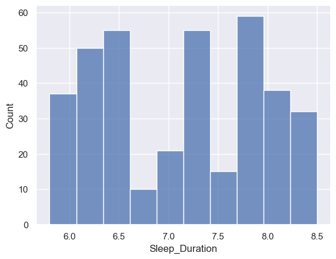

```python
sns.histplot(data = df, x = 'Sleep_Duration')
```

Для построения ядерной оценки воспользуемся параметром kde (Kernel Density Estimation), которая использует Гауссовские ядра (scipy.stats.gaussian_like) для сглаживания (согласно документации)

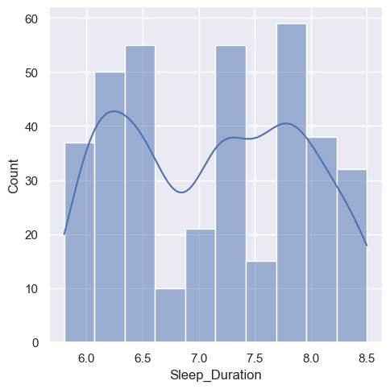

```python
sns.displot(data = df, x = 'Sleep_Duration', kde=True)
```

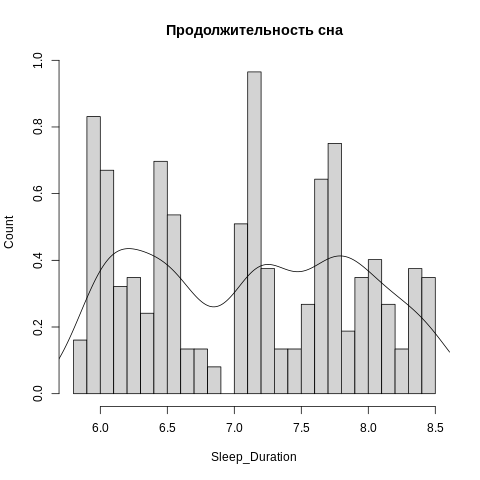

```python
%%R
sleep_duration <- df$Sleep.Duration
hist(sleep_duration, breaks = 20, freq = FALSE,
     xlab = "Sleep_Duration",
     ylab = "Count",
     main = "Продолжительность сна")
lines(density(sleep_duration))
```

### Задание 2

Реализовать анализ данных с помощью cdplot, dotchart, boxplot и stripchart.

Функция cdplot вычисляет и строит графики условных плотностей, описывающих, как изменяется условное распределение категориальной переменной y по числовой переменной x. В данном случае за y взят Gender, а за x Stress Level

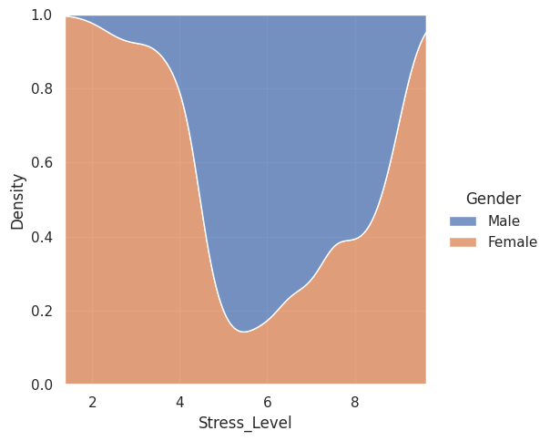

```python
sns.displot(data = df, hue = 'Gender', multiple = 'fill',  x = 'Stress_Level', kind = 'kde')
```

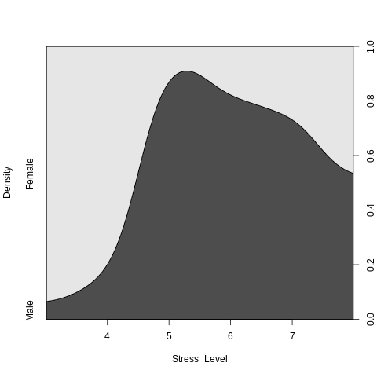

```python
%%R

df$factor <- factor(df$Gender)
cdplot(factor ~ df$Stress.Level,
       df,
       xlab = "Stress_Level",
       ylab = "Density")
```

Аналогом dotchart является scatterplot, который рисует точечный график Кливленда. В данном случае установим зависимость Physical Activity Level от Occupation.

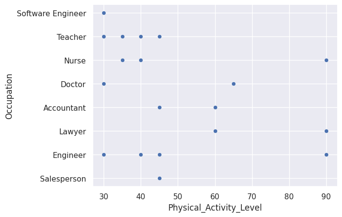

```python
sns.scatterplot(data = df[df['Sleep_Disorder'] == 'Insomnia'], x = 'Physical_Activity_Level', y = 'Occupation')
```

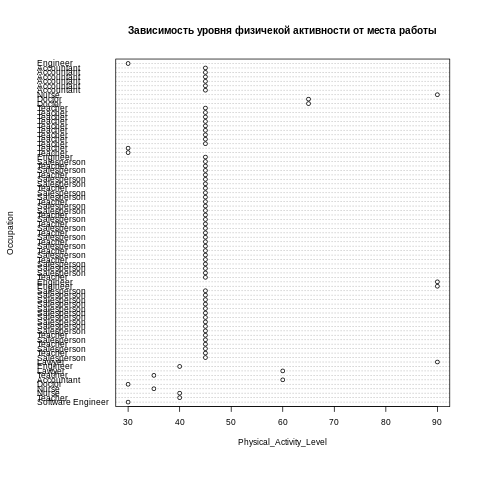

```python
%%R

grp_sleep_disorder = df[df$Sleep.Disorder == 'Insomnia',] %>% group_by(Physical.Activity.Level, Occupation)

dotchart(grp_sleep_disorder$Physical.Activity.Level, grp_sleep_disorder$Occupation,
         xlab = "Physical_Activity_Level",
         ylab = "Occupation",
         main = "Зависимость уровня физичекой активности от места работы",
         cex = 0.7)
```

Boxplot (или ящик-с-усами) показывает распределение количественных данных таким образом, чтобы облегчить сравнение между переменными или между уровнями категориальной переменной. В рамке показаны квартили набора данных, в то время как усики расширяются, чтобы показать остальную часть распределения, за исключением точек, которые определены как “выбросы” с использованием метода, который является функцией межквартильного диапазона. В данном случае представлена зависимость Daily_Steps от BMI_Category (Индекс Массы Тела)

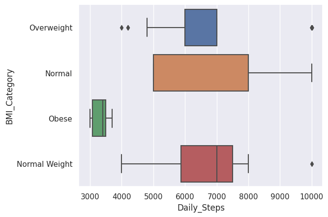

```python
sns.boxplot(data = df, x = 'Daily_Steps', y = 'BMI_Category')
```

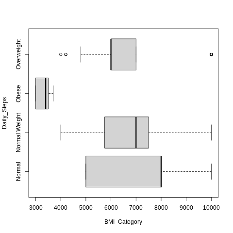

```python
%%R

boxplot(Daily.Steps ~ BMI.Category,
        df,
        xlab = "BMI_Category",
        ylab = "Daily_Steps",
        horizontal = TRUE)
```

Аналогом stripchart является stripplot. Рисует категориальную scatterplot, используя дрожание, чтобы уменьшить наложение. В данном случае показана зависимость Quality_of_Sleep от Age

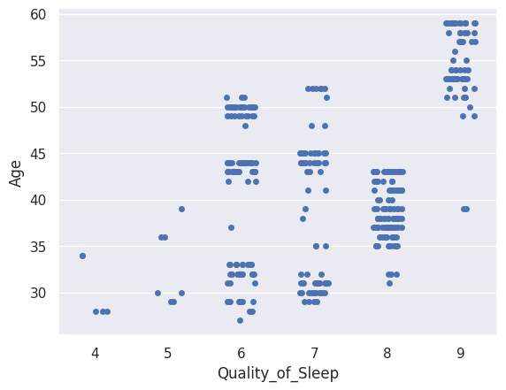

```python
sns.stripplot(data = df, x = 'Quality_of_Sleep', y = 'Age', jitter = 0.2)
```

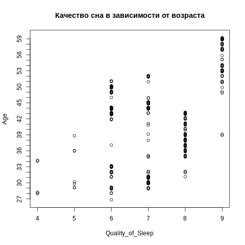

```python
%%R

stripchart(df$Quality.of.Sleep ~ df$Age,
           main = "Качество сна в зависимости от возраста",
           xlab = "Quality_of_Sleep",
           ylab = "Age",
           method = "jitter",
           jitter = 0.2,
           pch = 1)
```

### Задание 3

Проверить, являются ли наблюдения выбросами с точки зрения формальных статистических критериев Граббса и Q-теста Диксона. Визуализировать результаты.

Ограничение на тест Диксона 30 элементов, поэтому возьмем категорию Normal Weight в которой 21 элемент. Предположим, что основываясь на данных графика boxplot значение 10000 шагов является выбросом.  
Для этого выдвинем гипотезу, и проверим ее с помощью статистических критериев  
$H_0$ - Крайнее значение не является выбросом  
$H_1$ - Крайнее значение является выбросом

Критерий Смирнова-Граббса $$ \text{Статистика} \ G(X) = \frac{X - \overline{X}}{\sigma} \\ $$ $X$ - данные для проверки гипотезы
$\overline{X}$ - среднее от представленных данных
$\sigma$ - стандартное отклонение
Функция плотности для непрерывной случайной величины Стюдента: $$ f(x, \nu) = \frac{\Gamma((\nu + 1)/2)}{\sqrt{\pi\nu}\Gamma(\nu/2)} (1 + x^2/\nu)^{-(\nu+1)/2} \ $$ Доверительный интервал уровня $\alpha$: $$ P(T_1(X) \leq \eta \leq T_2(X)) = 1 - \alpha \ $$ для параметра $\eta$

```python
def grubbs_test(x, alpha=0.05):
   n = len(x)
   mean_x = np.mean(x)
   sd_x = np.std(x)
   numerator = max(abs(x-mean_x))
   g_calc = numerator/sd_x
   t_value = stats.t.ppf(1 - alpha / (2 * n), n - 2) # функция квантилей Precent Point Function
   g_crit = ((n - 1) * np.sqrt(np.square(t_value))) / (np.sqrt(n) * np.sqrt(n - 2 + np.square(t_value)))
   return g_calc > g_crit

grubbs_test(df[df['BMI_Category'] == 'Normal Weight']['Daily_Steps'])
```

```
False
```

```python
%%R

normal_weight = df[df$BMI.Category == 'Normal Weight', ]
steps <- normal_weight$Daily.Steps
grubbs.test(steps)
```

```
	Grubbs test for one outlier

data:  steps
G = 2.12824, U = 0.74906, p-value = 0.2446
alternative hypothesis: highest value 10000 is an outlier
```

Проверим аналогичную гипотезу с помощью Q теста Диксона $$ Q = \frac{gap}{range} $$

```python
def DixonQ_test(x):
    q_table = 0.337 # значение Q теста для коэффициента доверия 95% на 21 элементе
    x_s = sorted(x)
    q_calc = abs(x_s[-2] - x_s[-1])/abs(x_s[0] - x_s[-1])

    return q_calc > q_table

DixonQ_test(df[df['BMI_Category'] == 'Normal Weight']['Daily_Steps'])
```

```
False
```

```python
%%R

dixon.test(steps)
```

```
	Dixon test for outliers

data:  steps
Q = 0.33898, p-value = 0.4039
alternative hypothesis: highest value 10000 is an outlier
```

Аналогичный результат получаем для теста Диксона. Проиллюстрируем полученные результаты на графике

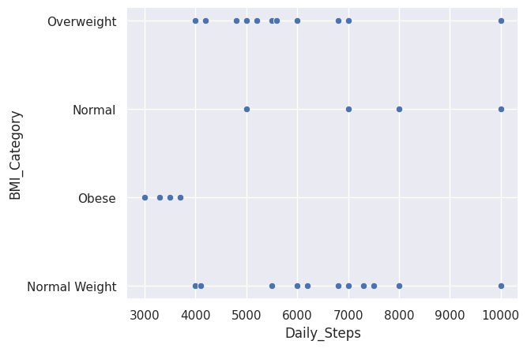

```python
sns.scatterplot(df, x = 'Daily_Steps', y = 'BMI_Category')
```

### Задание 4

Воспользоваться инструментами для заполнения пропусков в данных. Пропуски внести вручную и сравнить результаты заполнения с истинными значениями.

```python
short_df = df[50:200]
```

```python
print(short_df['Age'][114])
print(short_df['Sleep_Duration'][102])
print(short_df['Quality_of_Sleep'][146])
print(short_df['Physical_Activity_Level'][56])
print(short_df['Stress_Level'][182])
print(short_df['Heart_Rate'][135])
print(short_df['Daily_Steps'][87])
```

```
37
7.2
8
75
5
68
5000
```

```python
%%R

short_df <- df[37:364,]

print(short_df$Age[114])
print(short_df$Sleep.Duration[102])
print(short_df$Quality.of.Sleep[146])
print(short_df$Physical.Activity.Level[56])
print(short_df$Stress.Level[182])
print(short_df$Heart.Rate[135])
print(short_df$Daily.Steps[87])
```

```
[1] 39
[1] 7.1
[1] 8
[1] 60
[1] 5
[1] 70
[1] 7000
```

```python
short_df['Age'][114] = np.nan
short_df['Sleep_Duration'][102] = np.nan
short_df['Quality_of_Sleep'][146] = np.nan
short_df['Physical_Activity_Level'][56] = np.nan
short_df['Stress_Level'][182] = np.nan
short_df['Heart_Rate'][135] = np.nan
short_df['Daily_Steps'][87] = np.nan
```

```python
%%R

short_df$Age[114] = NA
short_df$Sleep.Duration[102] = NA
short_df$Quality.of.Sleep[146] = NA
short_df$Physical.Activity.Level[56] = NA
short_df$Stress.Level[182] = NA
short_df$Heart.Rate[135] = NA
short_df$Daily.Steps[87] = NA
```

```python
print(short_df['Age'][114])
print(short_df['Sleep_Duration'][102])
print(short_df['Quality_of_Sleep'][146])
print(short_df['Physical_Activity_Level'][56])
print(short_df['Stress_Level'][182])
print(short_df['Heart_Rate'][135])
print(short_df['Daily_Steps'][87])
```

```
nan
nan
nan
nan
nan
nan
nan
```

```python
%%R

print(short_df$Age[114])
print(short_df$Sleep.Duration[102])
print(short_df$Quality.of.Sleep[146])
print(short_df$Physical.Activity.Level[56])
print(short_df$Stress.Level[182])
print(short_df$Heart.Rate[135])
print(short_df$Daily.Steps[87])
```

```
[1] NA
[1] NA
[1] NA
[1] NA
[1] NA
[1] NA
[1] NA
```

Заполним средним

```python
short_df['Age'].fillna(int(short_df['Age'].mean()), inplace=True, downcast='infer')
short_df['Sleep_Duration'].fillna(short_df['Sleep_Duration'].mean(), inplace=True)
short_df['Quality_of_Sleep'].fillna(int(short_df['Quality_of_Sleep'].mean()), inplace=True, downcast='infer')
short_df['Physical_Activity_Level'].fillna(int(short_df['Physical_Activity_Level'].mean()), inplace=True, downcast='infer')
short_df['Stress_Level'].fillna(int(short_df['Stress_Level'].mean()), inplace=True, downcast='infer')
short_df['Heart_Rate'].fillna(int(short_df['Heart_Rate'].mean()), inplace=True, downcast='infer')
short_df['Daily_Steps'].fillna(int(short_df['Daily_Steps'].mean()), inplace=True, downcast='infer')
```

```python
%%R

mid <- mice(short_df, seed = 23000)
short_df <- complete(mid, action = 3)
```

```python
print(short_df['Age'][114])
print(short_df['Sleep_Duration'][102])
print(short_df['Quality_of_Sleep'][146])
print(short_df['Physical_Activity_Level'][56])
print(short_df['Stress_Level'][182])
print(short_df['Heart_Rate'][135])
print(short_df['Daily_Steps'][87])
```

```
37
6.997986577181209
7
56
5
70
6646
```

```python
%%R

print(short_df$Age[114])
print(short_df$Sleep.Duration[102])
print(short_df$Quality.of.Sleep[146])
print(short_df$Physical.Activity.Level[56])
print(short_df$Stress.Level[182])
print(short_df$Heart.Rate[135])
print(short_df$Daily.Steps[87])
```

```
[1] 40
[1] 7.2
[1] 8
[1] 42
[1] 5
[1] 70
[1] 7000
```

```python
short_df['Age'][114] = np.nan
short_df['Sleep_Duration'][102] = np.nan
short_df['Quality_of_Sleep'][146] = np.nan
short_df['Physical_Activity_Level'][56] = np.nan
short_df['Stress_Level'][182] = np.nan
short_df['Heart_Rate'][135] = np.nan
short_df['Daily_Steps'][87] = np.nan
```

И медианным значением

```python
short_df['Age'].fillna(int(short_df['Age'].median()), inplace=True, downcast='infer')
short_df['Sleep_Duration'].fillna(short_df['Sleep_Duration'].median(), inplace=True)
short_df['Quality_of_Sleep'].fillna(int(short_df['Quality_of_Sleep'].median()), inplace=True, downcast='infer')
short_df['Physical_Activity_Level'].fillna(int(short_df['Physical_Activity_Level'].median()), inplace=True, downcast='infer')
short_df['Stress_Level'].fillna(int(short_df['Stress_Level'].median()), inplace=True, downcast='infer')
short_df['Heart_Rate'].fillna(int(short_df['Heart_Rate'].median()), inplace=True, downcast='infer')
short_df['Daily_Steps'].fillna(int(short_df['Daily_Steps'].median()), inplace=True, downcast='infer')
```

```python
print(short_df['Age'][114])
print(short_df['Sleep_Duration'][102])
print(short_df['Quality_of_Sleep'][146])
print(short_df['Physical_Activity_Level'][56])
print(short_df['Stress_Level'][182])
print(short_df['Heart_Rate'][135])
print(short_df['Daily_Steps'][87])
```

```
37
7.2
8
60
5
70
7000
```

### Задание 5

Сгенерировать данные из нормального распределения с различными параметрами и провести анализ с помощью графиков эмпирических функций распределений, квантилей, метода огибающих, а также стандартных процедур проверки гипотез о нормальности (критерии Колмогорова-Смирнова, Шапиро- Уилка, Андерсона-Дарлинга, Крамера фон Мизеса, Колмогорова-Смирнова в модификации Лиллиефорса и Шапиро-Франсия). Рассмотреть выборки малого (не более 50-100 элементов) и умеренного (1000-5000 наблюдений) объемов.

```python
norm_1 = np.random.normal(0, 1, size=50)
norm_2 = np.random.normal(1, 1, size=100)
norm_3 = np.random.normal(0, 5, size=1000)
norm_4 = np.random.normal(5, 5, size=5000)
```

```python
%%R

norm_1 <- rnorm(50, 0, 1)
norm_2 <- rnorm(100, 1, 1)
norm_3 <- rnorm(1000, 0, 5)
norm_4 <- rnorm(5000, 5, 5)
```

Стандартным нормальным распределением $N(0,1)$ является только norm_1

##### Эмпирические функции распределения (ECDF)

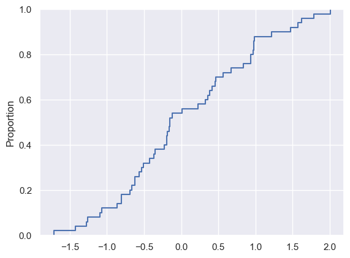

```python
sns.ecdfplot(data = norm_1)
```

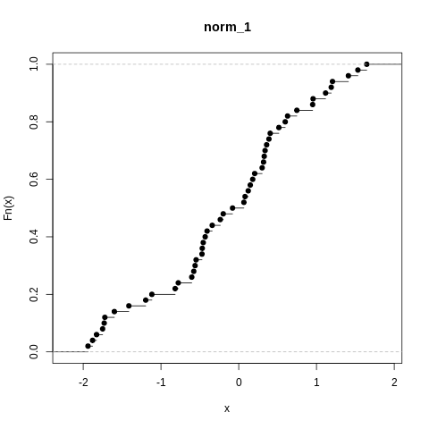

```python
%%R

plot(ecdf(norm_1), main = "norm_1")
```

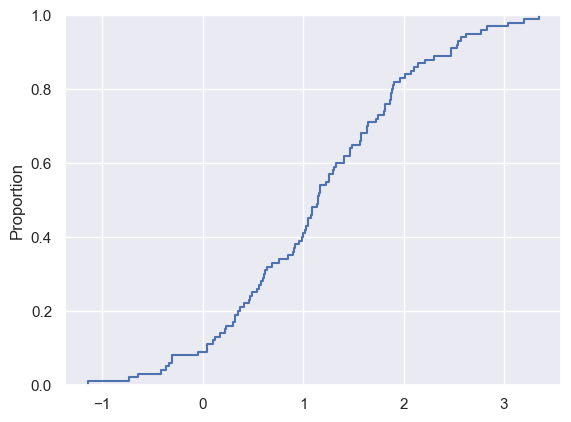

```python
sns.ecdfplot(data = norm_2)
```

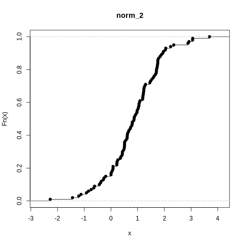

```python
%%R

plot(ecdf(norm_2), main = "norm_2")
```

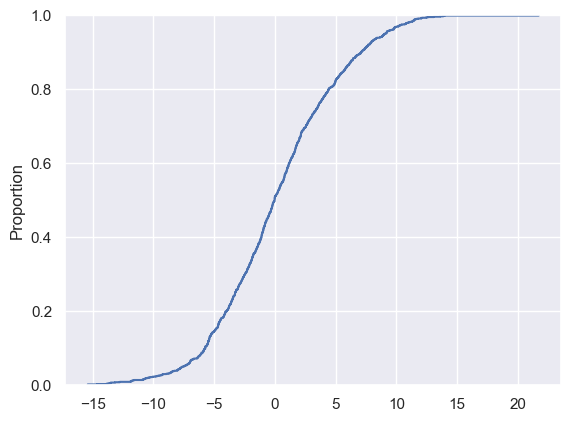

```python
sns.ecdfplot(data = norm_3)
```

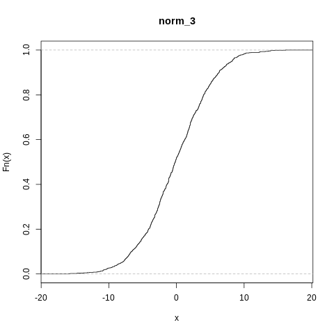

```python
%%R

plot(ecdf(norm_3), main = "norm_3")
```

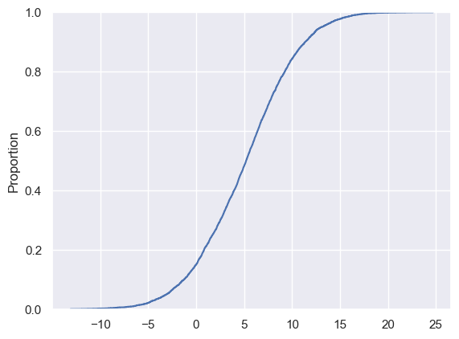

```python
sns.ecdfplot(data = norm_4)
```

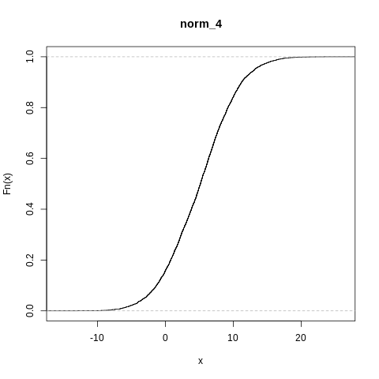

```python
%%R

plot(ecdf(norm_4), main = "norm_4")
```

##### Квантили

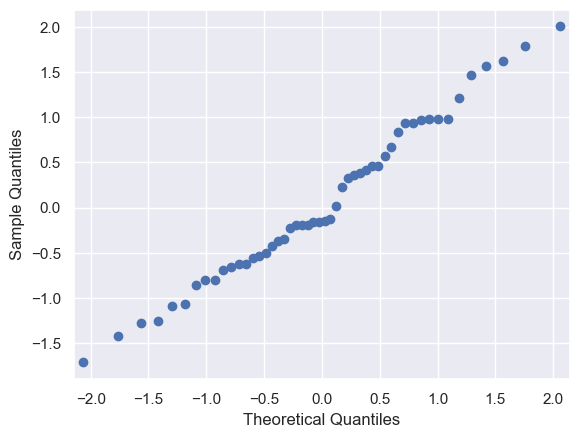

```python
stm.qqplot(norm_1)
plt.show()
```

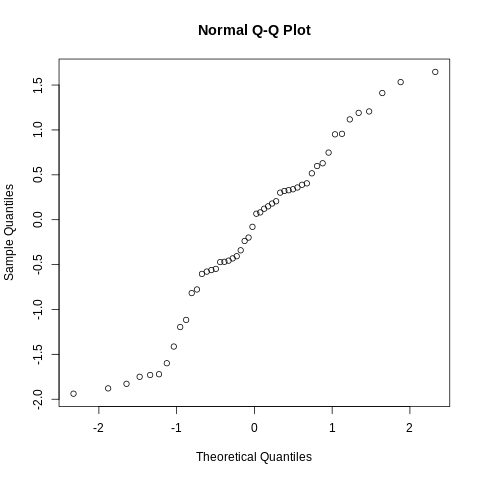

```python
%%R

qqnorm(norm_1)
```

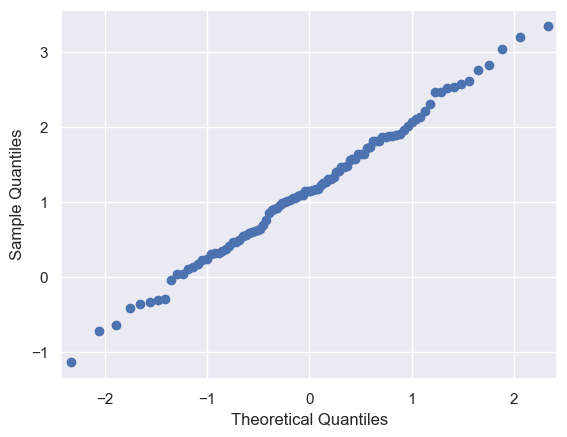

```python
stm.qqplot(norm_2)
plt.show()
```

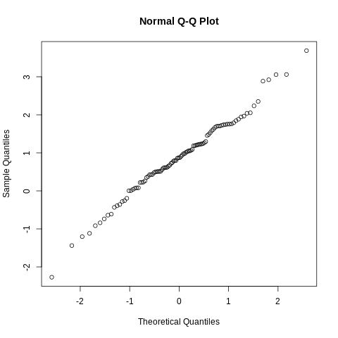

```python
%%R

qqnorm(norm_2)
```

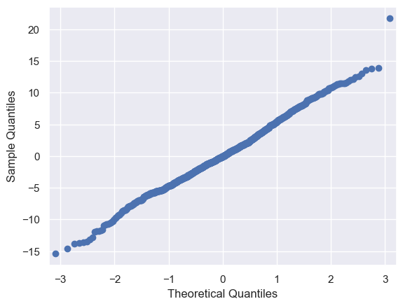

```python
stm.qqplot(norm_3)
plt.show()
```

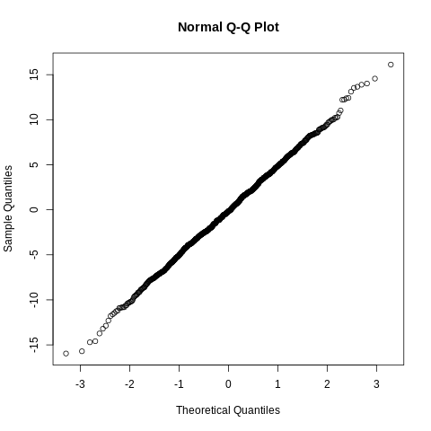

```python
%%R

qqnorm(norm_3)
```

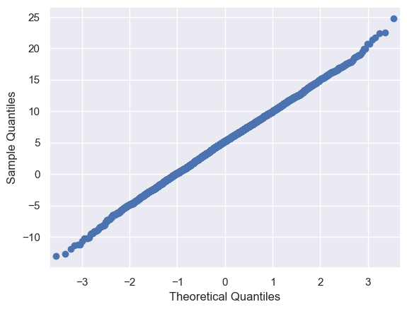

```python
stm.qqplot(norm_4)
plt.show()
```

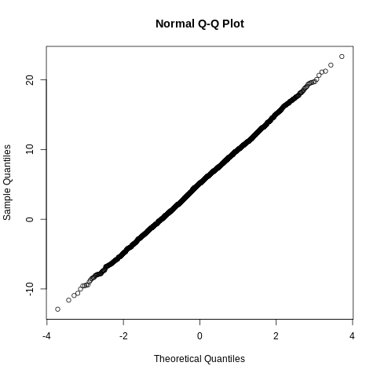

```python
%%R

qqnorm(norm_4)
```

##### Стандартные процедуры проверки гипотез нормальности

Критерий Колмогорова-Смирнова

```python
from scipy.stats import kstest
print('exp = 0, var = 1', kstest(norm_1, 'norm'))
print('exp = 1, var = 1', kstest(norm_2, 'norm'))
print('exp = 0, var = 5', kstest(norm_3, 'norm'))
print('exp = 5, var = 5', kstest(norm_4, 'norm'))
```

```
exp = 0, var = 1 KstestResult(statistic=0.08890042403267828, pvalue=0.7914671705707594, statistic_location=-0.12288375224712625, statistic_sign=1)
exp = 1, var = 1 KstestResult(statistic=0.46560439840961887, pvalue=2.2060383901602836e-20, statistic_location=0.8987399296172925, statistic_sign=-1)
exp = 0, var = 5 KstestResult(statistic=0.3189325449547473, pvalue=5.776195395036097e-91, statistic_location=1.644199936417095, statistic_sign=-1)
exp = 5, var = 5 KstestResult(statistic=0.7122350796977276, pvalue=0.0, statistic_location=2.0843335170773942, statistic_sign=-1)
```

```python
%%R

print(ks.test(norm_1, "pnorm"))
print(ks.test(norm_2, "pnorm"))
print(ks.test(norm_3, "pnorm"))
print(ks.test(norm_4, "pnorm"))
```

```
	Exact one-sample Kolmogorov-Smirnov test

data:  norm_1
D = 0.10279, p-value = 0.6289
alternative hypothesis: two-sided


	Asymptotic one-sample Kolmogorov-Smirnov test

data:  norm_2
D = 0.39403, p-value = 6.539e-14
alternative hypothesis: two-sided


	Asymptotic one-sample Kolmogorov-Smirnov test

data:  norm_3
D = 0.3412, p-value < 2.2e-16
alternative hypothesis: two-sided


	Asymptotic one-sample Kolmogorov-Smirnov test

data:  norm_4
D = 0.70412, p-value < 2.2e-16
alternative hypothesis: two-sided
```

$H_0$: распределение соответствует стандартному нормальному распределению

$H_1$: распределение не соответствует стандартному нормальному распределению

pvalue при уровне значимости 0.05 оказался больше только у первого нормального распределения, что соответствует предположению о его стандартности

Критерий Шапиро-Уилка

```python
from scipy.stats import shapiro
print('exp = 0, var = 1', shapiro(norm_1))
print('exp = 1, var = 1', shapiro(norm_2))
print('exp = 0, var = 5', shapiro(norm_3))
print('exp = 5, var = 5', shapiro(norm_4))
```

```
exp = 0, var = 1 ShapiroResult(statistic=0.9780240058898926, pvalue=0.47197356820106506)
exp = 1, var = 1 ShapiroResult(statistic=0.9954039454460144, pvalue=0.9842053055763245)
exp = 0, var = 5 ShapiroResult(statistic=0.995875895023346, pvalue=0.008961324580013752)
exp = 5, var = 5 ShapiroResult(statistic=0.9995540380477905, pvalue=0.3097327649593353)
```

```python
%%R

print(shapiro.test(norm_1))
print(shapiro.test(norm_2))
print(shapiro.test(norm_3))
print(shapiro.test(norm_4))
```

```
	Shapiro-Wilk normality test

data:  norm_1
W = 0.96583, p-value = 0.1559


	Shapiro-Wilk normality test

data:  norm_2
W = 0.98817, p-value = 0.5212


	Shapiro-Wilk normality test

data:  norm_3
W = 0.99915, p-value = 0.9392


	Shapiro-Wilk normality test

data:  norm_4
W = 0.99971, p-value = 0.7218
```

$H_0$: данные имеют нормальное распределение

$H_1$: данные не имеют нормальное распределение

Критерий Андерсона-Дарлинга

```python
from scipy.stats import anderson
print('exp = 0, var = 1', anderson(norm_1))
print('exp = 1, var = 1', anderson(norm_2))
print('exp = 0, var = 5', anderson(norm_3))
print('exp = 5, var = 5', anderson(norm_4))
```

```
exp = 0, var = 1 AndersonResult(statistic=0.4032617981346718, critical_values=array([0.538, 0.613, 0.736, 0.858, 1.021]), significance_level=array([15. , 10. ,  5. ,  2.5,  1. ]), fit_result=  params: FitParams(loc=0.06304667143496266, scale=0.8991515119906652)
 success: True
 message: '`anderson` successfully fit the distribution to the data.')
exp = 1, var = 1 AndersonResult(statistic=0.13469544889564133, critical_values=array([0.555, 0.632, 0.759, 0.885, 1.053]), significance_level=array([15. , 10. ,  5. ,  2.5,  1. ]), fit_result=  params: FitParams(loc=1.1660093851290687, scale=0.9171592969515826)
 success: True
 message: '`anderson` successfully fit the distribution to the data.')
exp = 0, var = 5 AndersonResult(statistic=1.2558044184712571, critical_values=array([0.574, 0.653, 0.784, 0.914, 1.088]), significance_level=array([15. , 10. ,  5. ,  2.5,  1. ]), fit_result=  params: FitParams(loc=0.233760585691112, scale=5.052389678299795)
 success: True
 message: '`anderson` successfully fit the distribution to the data.')
exp = 5, var = 5 AndersonResult(statistic=0.6424519414504175, critical_values=array([0.576, 0.655, 0.786, 0.917, 1.091]), significance_level=array([15. , 10. ,  5. ,  2.5,  1. ]), fit_result=  params: FitParams(loc=5.090999833331517, scale=4.953423457669129)
 success: True
 message: '`anderson` successfully fit the distribution to the data.')
```

```python
%%R

print(ad.test(norm_1))
print(ad.test(norm_2))
print(ad.test(norm_3))
print(ad.test(norm_4))
```

```
	Anderson-Darling normality test

data:  norm_1
A = 0.46106, p-value = 0.2492


	Anderson-Darling normality test

data:  norm_2
A = 0.42462, p-value = 0.3116


	Anderson-Darling normality test

data:  norm_3
A = 0.16966, p-value = 0.9337


	Anderson-Darling normality test

data:  norm_4
A = 0.58837, p-value = 0.1252
```

Критерий Крамера фон Мизеса

```python
from scipy.stats import cramervonmises
print('exp = 0, var = 1', cramervonmises(norm_1, 'norm'))
print('exp = 1, var = 1', cramervonmises(norm_2, 'norm'))
print('exp = 0, var = 5', cramervonmises(norm_3, 'norm'))
print('exp = 5, var = 5', cramervonmises(norm_4, 'norm'))
```

```
exp = 0, var = 1 CramerVonMisesResult(statistic=0.05987607325085499, pvalue=0.8170255053893085)
exp = 1, var = 1 CramerVonMisesResult(statistic=11.096229009960297, pvalue=2.5698376759919483e-10)
exp = 0, var = 5 CramerVonMisesResult(statistic=43.22013538101359, pvalue=5.901304889199821e-09)
exp = 5, var = 5 CramerVonMisesResult(statistic=877.4696055187985, pvalue=1.985161283135639e-07)
```

```python
%%R

print(cvm.test(norm_1))
print(cvm.test(norm_2))
print(cvm.test(norm_3))
print(cvm.test(norm_4))
```

```
	Cramer-von Mises normality test

data:  norm_1
W = 0.06131, p-value = 0.3569


	Cramer-von Mises normality test

data:  norm_2
W = 0.062357, p-value = 0.349


	Cramer-von Mises normality test

data:  norm_3
W = 0.026062, p-value = 0.8956


	Cramer-von Mises normality test

data:  norm_4
W = 0.11384, p-value = 0.07272
```

$H_0$: распределение соответствует стандартному нормальному распределению

$H_1$: распределение не соответствует стандартному нормальному распределению

pvalue при уровне значимости 0.05 оказался больше только у первого нормального распределения, что соответствует предположению о его стандартности

```python
from statsmodels.stats.diagnostic import lilliefors
print('exp = 0, var = 1', lilliefors(norm_1, 'norm'))
print('exp = 1, var = 1', lilliefors(norm_2, 'norm'))
print('exp = 0, var = 5', lilliefors(norm_3, 'norm'))
print('exp = 5, var = 5', lilliefors(norm_4, 'norm'))
```

```
exp = 0, var = 1 (0.12191084436577182, 0.06089824339722899)
exp = 1, var = 1 (0.0387157876378621, 0.9704999009504235)
exp = 0, var = 5 (0.03373234123491298, 0.014142945106621155)
exp = 5, var = 5 (0.01380566370663261, 0.022726914944138123)
```

```python
%%R

print(lillie.test(norm_1))
print(lillie.test(norm_2))
print(lillie.test(norm_3))
print(lillie.test(norm_4))
```

```
	Lilliefors (Kolmogorov-Smirnov) normality test

data:  norm_1
D = 0.088514, p-value = 0.4229


	Lilliefors (Kolmogorov-Smirnov) normality test

data:  norm_2
D = 0.062584, p-value = 0.436


	Lilliefors (Kolmogorov-Smirnov) normality test

data:  norm_3
D = 0.015769, p-value = 0.7908


	Lilliefors (Kolmogorov-Smirnov) normality test

data:  norm_4
D = 0.011196, p-value = 0.1346
```

$H_0$: данные имеют нормальное распределение

$H_1$: данные не имеют нормальное распределение

### Задание 6

Продемонстрировать пример анализа данных с помощью графиков квантилей, метода огибающих, а также стандартных процедур проверки гипотез о нормальности. Рассмотреть выборки малого и умеренного объемов.

Для расширения выборки воспользуемся менее развернутым, но более объемным датасетом Time Americans Spend Sleeping. По существу нас будет интересовать только две колонки Year и Avg hrs per day sleeping

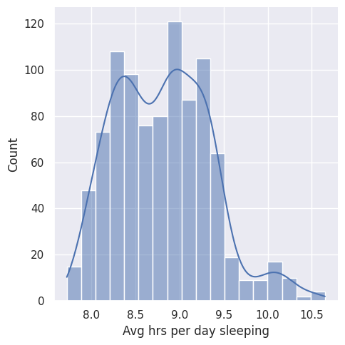

```python
huge = pd.read_csv('Time Americans Spend Sleeping.csv')
# умереная выборка
medium_df = huge['Avg hrs per day sleeping']
sns.displot(data = medium_df, kde=True)
```

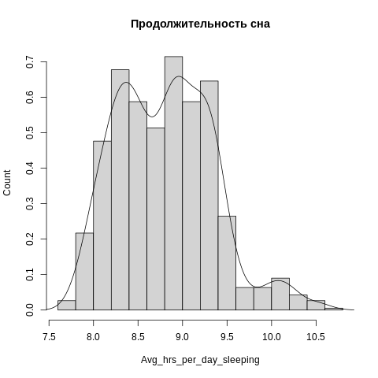

```python
%%R

huge <- read.csv("Time Americans Spend Sleeping.csv")
rownames(df) <- NULL

medium_df = huge$Avg.hrs.per.day.sleeping
hist(medium_df, breaks = 20, freq = FALSE,
     xlab = "Avg_hrs_per_day_sleeping",
     ylab = "Count",
     main = "Продолжительность сна")
lines(density(medium_df))
```

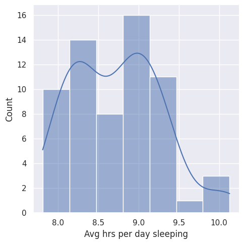

```python
# малая выборка
small_df = huge[huge['Year'] == 2008]['Avg hrs per day sleeping']
sns.displot(data = small_df, kde=True)
```

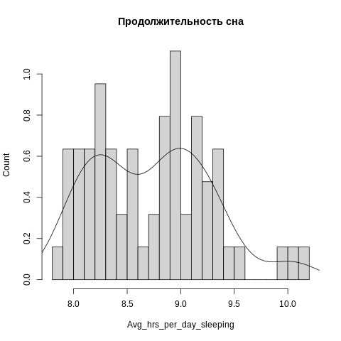

```python
%%R

small_df = huge[huge$Year == 2008,]$Avg.hrs.per.day.sleeping
hist(small_df, breaks = 20, freq = FALSE,
     xlab = "Avg_hrs_per_day_sleeping",
     ylab = "Count",
     main = "Продолжительность сна")
lines(density(small_df))
```

Квантили

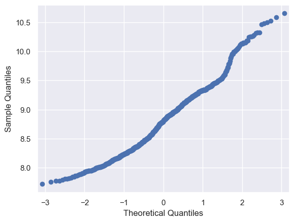

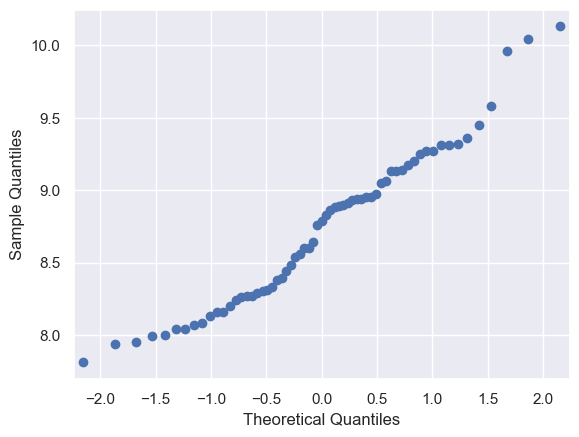

```python
stm.qqplot(medium_df)
stm.qqplot(small_df)
plt.show()
```

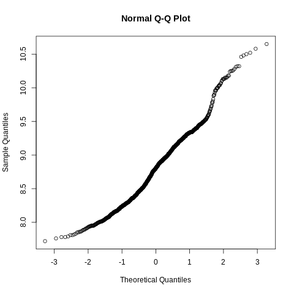

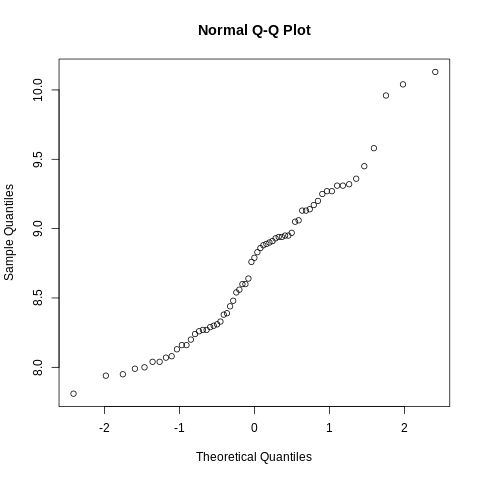

```python
%%R

qqnorm(medium_df)
qqnorm(small_df)
```

По построенной ядерной оценке видно, что график немного похож на шляпу нормального распределения. Проверим эту гипотезу с помощью ранее проверенных инструментов

```python
print("\nУмеренная выборка:\n")
print(kstest(medium_df, 'norm'))
print(shapiro(medium_df))
print(anderson(medium_df))
print(cramervonmises(medium_df, 'norm'))
print(lilliefors(medium_df, 'norm'))

print("\nМалая выборка:\n")
print(kstest(small_df, 'norm'))
print(shapiro(small_df))
print(anderson(small_df))
print(cramervonmises(small_df, 'norm'))
print(lilliefors(small_df, 'norm'))
```

```
Умеренная выборка:

KstestResult(statistic=0.9999999999999942, pvalue=0.0, statistic_location=7.72, statistic_sign=-1)
ShapiroResult(statistic=0.9755359292030334, pvalue=1.6428273671986737e-11)
AndersonResult(statistic=4.587391586589661, critical_values=array([0.574, 0.653, 0.784, 0.914, 1.087]), significance_level=array([15. , 10. ,  5. ,  2.5,  1. ]), fit_result=  params: FitParams(loc=8.806867724867725, scale=0.545001291074517)
 success: True
 message: '`anderson` successfully fit the distribution to the data.')
CramerVonMisesResult(statistic=314.9999999999998, pvalue=8.81229155202945e-08)
(0.058353445295202255, 0.0009999999999998899)

Малая выборка:

KstestResult(statistic=0.9999999999999971, pvalue=0.0, statistic_location=7.81, statistic_sign=-1)
ShapiroResult(statistic=0.9591192603111267, pvalue=0.035100728273391724)
AndersonResult(statistic=0.7289237707380565, critical_values=array([0.545, 0.621, 0.744, 0.868, 1.033]), significance_level=array([15. , 10. ,  5. ,  2.5,  1. ]), fit_result=  params: FitParams(loc=8.731746031746033, scale=0.5475680534595521)
 success: True
 message: '`anderson` successfully fit the distribution to the data.')
CramerVonMisesResult(statistic=20.999999999999982, pvalue=1.962535911559371e-09)
(0.10176494618135945, 0.1426585608730208)
```

```python
%%R

print("Умеренная выборка")
print(ks.test(medium_df, "pnorm"))
print(shapiro.test(medium_df))
print(ad.test(medium_df))
print(cvm.test(medium_df))
print(lillie.test(medium_df))

print("Малая выборка")
print(ks.test(small_df, "pnorm"))
print(shapiro.test(small_df))
print(ad.test(small_df))
print(cvm.test(small_df))
print(lillie.test(small_df))
```

```
[1] "Умеренная выборка"

	Asymptotic one-sample Kolmogorov-Smirnov test

data:  medium_df
D = 1, p-value < 2.2e-16
alternative hypothesis: two-sided


	Shapiro-Wilk normality test

data:  medium_df
W = 0.97553, p-value = 1.638e-11


	Anderson-Darling normality test

data:  medium_df
A = 4.5874, p-value = 2.234e-11


	Cramer-von Mises normality test

data:  medium_df
W = 0.57038, p-value = 6.469e-07


	Lilliefors (Kolmogorov-Smirnov) normality test

data:  medium_df
D = 0.058353, p-value = 4.788e-08

[1] "Малая выборка"

	Asymptotic one-sample Kolmogorov-Smirnov test

data:  small_df
D = 1, p-value < 2.2e-16
alternative hypothesis: two-sided

```

[output cut: 8 more lines]

```

data:  small_df
A = 0.72892, p-value = 0.0545


	Cramer-von Mises normality test

data:  small_df
W = 0.1079, p-value = 0.08532


	Lilliefors (Kolmogorov-Smirnov) normality test

data:  small_df
D = 0.10176, p-value = 0.1083
```

Это задание было создано вопреки колонкам: Quality of Sleep, Sleep Duration, Physical Activity Level, Stress Level и Daily Steps :)